# Interplay of Nutritional Factors and Allergic Outcomes

BMIN5030/EPID600 Final Project

Author

Stan Gabryszewski

## 1 Overview

**Give a brief a description of your project and its goal(s), what data you are using to complete it, and what two faculty/staff in different fields you have spoken to about your project with a brief summary of what you learned from each person. Include a link to your final project GitHub repository.**

This project will analyze data from the National Health and Nutrition Examination Survey (NHANES) to explore links between nutritional factors and allergic diseases in the U.S. population. Using regression modeling and machine learning methods, the study will examine how dietary patterns, growth metrics, and nutritional biomarkers associate with allergic outcomes, including atopic dermatitis (AD), IgE-mediated food allergy (IgE-FA), asthma, and allergic rhinitis (AR). This analysis has the potential to identify modifiable nutritional factors that influence allergic health trajectories.

The two faculty with who I discussed this project are Dr. Robert Grundmeier (Professor of Pediatrics at CHOP and Penn, Department of Biomedical and Health Informatics) and Dr. Rich Tsui (Professor of Anesthesiology and Critical Care at CHOP and Penn, Department of Anesthesiology and Critical Care Medicine). With Dr. Grundmeier, I discussed the analytic framework for defining allergic disease cohorts within the NHANES database. With both Dr. Grundmeier and Dr. Tsui, I discussed the selection, application, validation, interpretation, and visualization of machine learning approaches that will be used to identify nutritional predictors of allergic disease risk.

**GitHub repository link:** [Final Project Repo](https://github.com/gabryszews/BMIN503_Final_Project)

## 2 Introduction

**Describe the problem addressed, its significance, and some background to motivate the problem. This should extend what is in the Section 1. Explain why your problem is interdisciplinary, what fields can contribute to its understanding, and incorporate background related to what you learned from meeting with faculty/staff.**

The allergic march – typically progressing from AD to IgE-FA, asthma, AR, and eventually EoE – serves as a population-level paradigm for the sequential development of allergic diseases. Globally, the prevalence of allergic disorders has risen sharply in recent decades, yet how environmental and heritable factors interplay to influence these outcomes remains incompletely understood. Among them, nutrition is an important and incompletely explored domain. Nutritional exposures shape immune development, epithelial barrier integrity, and microbial diversity, all of which may modulate allergic risk. A clearer understanding of how nutritional factors contribute to allergy onset and progression could inform new strategies for prevention and management. To date, few analyses have comprehensively integrated information about nutritional status (e.g. anthropometrics, dietary intake, biomarker data) and allergic outcomes within a nationally representative cohort. The extensive nutritional and health data available in the National Health and Nutrition Examination Survey (NHANES) database provide a unique opportunity to address this gap and generate data-driven hypotheses.

The questions addressed in this project are inherently multidisciplinary, spanning allergy-immunology, clinical nutrition, statistics, epidemiology, and informatics. Knowledge in allergy-immunology is needed for a clinical and immunological framework, while knowledge in clinical nutrition is needed to contextualize anthropometric and dietary data. Moreover, knowledge in epidemiology is needed for a population-level understanding of disease patterns as well as understanding of how to account for study survey design, and lastly informatics knowledge is needed for data analysis. By integrating these disciplines, this project aims to identify and interpret relationships between various nutritional factors and allergic disease risk. I am positioned to undertake this work, drawing on my dual clinical experience in allergy-immunology and clinical nutrition, my supplemental training in epidemiology, and my ongoing learning in biomedical informatics, as facilitated by my coursework and support from my mentorship team (Drs. Robert Grundmeier and Rich Tsui).

## 3 Methods

**Describe the data used and general methodological approach used to address the problem described in the Section 2. Subsequently, incorporate full R code necessary to retrieve and clean data, and perform analysis. Be sure to include a description of code so that others (including your future self) can understand what you are doing and why.**

Thus far, I have downloaded NHANES survey data for select variables of interest, and these have been combined into an analytic dataset. As there are inconsistencies in variables across survey years, this is a work in progress. Of note, when I initiated the study, I wanted to examine allergy rates in children but then discovered that the data for children more scarce, including no data for eczema, food allergy, or allergic rhinitis for many survey cycles. As such, I shifted the analysis to focus on the 20-40 age range. The data preparation section below includes a plot of the non-missingness of select NHANES variables, and I will add additional variables in the coming days. In addition an exploratory weighted vs. unweighted logistic regression is included in the Results section.

**Install and load packages**

```r
# Install packages
install.packages("broom")
install.packages("cowplot")
install.packages("nhanesA")
install.packages("scales")
install.packages("srvyr")
install.packages("survey")
install.packages("tidyverse")
```

```r
# Load packages
library(broom)
library(cowplot)
library(nhanesA)
library(scales)
library(srvyr)
library(survey)
library(tidyverse)
```

**Prepare dataset**

```r
# Data handling functions --------------------------------------------------------------------

## Define NHANES cycles (i.e., 2007–2018, E–J)
cycles <- c("E", "F", "G", "H", "I", "J")

## Load NHANES module across multiple cycles
load_nhanes_module <- function(module, cycles_vec = cycles, keep_vars = NULL) {

  ### Create file tags with cycle label (e.g., DEMO-->DEMO_E)
  module_years <- paste0(module, "_", cycles_vec)

  ### Create status tibble to track download success and row counts
  status <- tibble(
    file_tag = module_years,
    ok       = FALSE,
    n_rows   = NA_integer_,
    note     = NA_character_
  )

  ### Create list to hold data frames for each cycle
  dfs <- vector("list", length(module_years))

  ### Loop over each module-year combination
  for (i in seq_along(module_years)) {
    x <- module_years[i]

    out <- tryCatch(
      {
        message("Attempting to download: ", x)

        #### Download data from nhanesA and convert to data frame
        df <- nhanes(x) |> as.data.frame()

        #### Select only variables from keep_vars
        if (!is.null(keep_vars)) {
          df <- df |>
            select(any_of(keep_vars))
        }

        #### Record how many rows were loaded
        n <- nrow(df)
        status$n_rows[i] <- n

        if (n == 0) {
          ##### Record if empty table and drop
          status$ok[i]   <- FALSE
          status$note[i] <- "Downloaded, 0 rows"
          warning("File ", x, " downloaded but has 0 rows.")
          df <- NULL
        } else {
          ##### For successful load, mark OK and store file tag
          status$ok[i]   <- TRUE
          status$note[i] <- "Loaded"
          df$file_tag    <- x
        }

        df
      },
      error = function(e) {
        ##### If download fails, capture error and continue
        status$ok[i]   <- FALSE
        status$note[i] <- paste("ERROR:", conditionMessage(e))
        warning("File ", x, " could not be downloaded: ", conditionMessage(e))
        return(NULL)
      }
    )

    ### Store result for cycle
    dfs[[i]] <- out
  }

  ### Keep only non-null data frames
  dfs_nonempty <- dfs[!vapply(dfs, is.null, logical(1))]

  ### Print summary table of load status
  message("\nSummary for module ", module, ":")
  print(status)

  ### Give error if nothing loaded
  if (length(dfs_nonempty) == 0) {
    stop("No cycles successfully downloaded for module: ", module)
  }

  ### Bind all (non-empty) cycles into one data frame
  bind_rows(dfs_nonempty)
}

## Convert yes/no codes to 0/1 (1 yes; 0 no; or NA)
to01 <- function(x) {
  x <- as.character(x)
  case_when(
    x %in% c("1", "Yes", "YES", "yes") ~ 1,
    x %in% c("2", "No",  "NO",  "no")  ~ 0,
    TRUE ~ NA_real_
  )
}

## Convert SDDSRVYR into a year-range cycle label
cycle_label <- function(s) {
  # Try to pull out "2007-2008" style years from labels like "NHANES 2007-2008 Public Release"
  years <- str_extract(as.character(s), "\\d{4}-\\d{4}")

  case_when(
    # If the label already contains a year range, use it
    !is.na(years) ~ years,

    # If not, use SDDSRVYR codes (5–10)
    TRUE ~ recode(
      as.numeric(s),
      `5`  = "2007-2008",
      `6`  = "2009-2010",
      `7`  = "2011-2012",
      `8`  = "2013-2014",
      `9`  = "2015-2016",
      `10` = "2017-2018",
      .default = NA_character_
    )
  )
}

## Check variable availability by NHANES cycle (including missingness)
check_var_availability <- function(data, vars = NULL) {

  # If no vars supplied, default to all columns except for IDs, weights, etc.
  if (is.null(vars)) {
    vars <- setdiff(
      names(data),
      c("seqn", "wtint2yr", "wtmec2yr", "wtint12yr", "wtmec12yr",
        "sdmvpsu", "sdmvstra", "sddsrvyr", "cycle_str")
    )
  }

  map_dfr(vars, function(v) {
    data |>
      group_by(cycle = sddsrvyr) |>
      summarise(
        variable      = v,
        total         = n(),
        n_nonmissing  = sum(!is.na(.data[[v]])),
        n_missing     = sum(is.na(.data[[v]])),
        prop_missing  = mean(is.na(.data[[v]])),
        .groups       = "drop"
      )
  }) |>
    arrange(variable, cycle)
}

# Load modules with selected variables --------------------------------------------------------

## DEMO module: demographics, design variables, and weights
demo_keep <- c(
  "SEQN",       # participant ID
  "RIDAGEYR",   # age in years at screening
  "RIAGENDR",   # sex (1 = male; 2 = female)
  "RIDRETH1",   # race/ethnicity (original coding; early cycles)
  "RIDRETH3",   # race/ethnicity (updated coding; later cycles)
  "DMDEDUC2",   # education level
  "INDFMPIR",   # family poverty-to-income ratio
  "INDHHIN2",   # household income category
  "SDDSRVYR",   # 2-year survey cycle indicator (5–10 for 2007–2018)
  "SDMVPSU",    # primary sampling unit
  "SDMVSTRA",   # sampling strata
  "WTINT2YR",   # 2-year interview weight
  "WTMEC2YR",   # 2-year MEC exam/lab weight
  "RIDEXPRG"    # pregnancy status
)

demo <- load_nhanes_module("DEMO", keep_vars = demo_keep)
```

```
Attempting to download: DEMO_E
```

```
Attempting to download: DEMO_F
```

```
Attempting to download: DEMO_G
```

```
Attempting to download: DEMO_H
```

```
Attempting to download: DEMO_I
```

```
Attempting to download: DEMO_J
```

```
Summary for module DEMO:
```

```
# A tibble: 6 × 4
  file_tag ok    n_rows note
  <chr>    <lgl>  <int> <chr>
1 DEMO_E   TRUE   10149 Loaded
2 DEMO_F   TRUE   10537 Loaded
3 DEMO_G   TRUE    9756 Loaded
4 DEMO_H   TRUE   10175 Loaded
5 DEMO_I   TRUE    9971 Loaded
6 DEMO_J   TRUE    9254 Loaded
```

```r
## MCQ module: self-reported allergic conditions
mcq_keep <- c(
  "SEQN",      # participant ID
  "MCQ160A",   # eczema/atopic dermatitis
  "MCQ160F",   # food allergy
  "MCQ010",    # asthma
  "MCQ160B"    # hay fever/allergic rhinitis
)

mcq <- load_nhanes_module("MCQ", keep_vars = mcq_keep)
```

```
Attempting to download: MCQ_E
```

```
Attempting to download: MCQ_F
```

```
Attempting to download: MCQ_G
```

```
Attempting to download: MCQ_H
```

```
Attempting to download: MCQ_I
```

```
Attempting to download: MCQ_J
```

```
Summary for module MCQ:
```

```
# A tibble: 6 × 4
  file_tag ok    n_rows note
  <chr>    <lgl>  <int> <chr>
1 MCQ_E    TRUE    9666 Loaded
2 MCQ_F    TRUE   10109 Loaded
3 MCQ_G    TRUE    9364 Loaded
4 MCQ_H    TRUE    9770 Loaded
5 MCQ_I    TRUE    9575 Loaded
6 MCQ_J    TRUE    8897 Loaded
```

```r
## BMX module: anthropometry
bmx_keep <- c(
  "SEQN",      # participant ID
  "BMXBMI",    # body mass index (kg/m^2)
  "BMXWAIST",  # waist circumference (cm)
  "BMXHT",     # standing height (cm)
  "BMXWT"      # body weight (kg)
)

bmx <- load_nhanes_module("BMX", keep_vars = bmx_keep)
```

```
Attempting to download: BMX_E
```

```
Attempting to download: BMX_F
```

```
Attempting to download: BMX_G
```

```
Attempting to download: BMX_H
```

```
Attempting to download: BMX_I
```

```
Attempting to download: BMX_J
```

```
Summary for module BMX:
```

```
# A tibble: 6 × 4
  file_tag ok    n_rows note
  <chr>    <lgl>  <int> <chr>
1 BMX_E    TRUE    9762 Loaded
2 BMX_F    TRUE   10253 Loaded
3 BMX_G    TRUE    9338 Loaded
4 BMX_H    TRUE    9813 Loaded
5 BMX_I    TRUE    9544 Loaded
6 BMX_J    TRUE    8704 Loaded
```

```r
## VID module: vitamin D lab
vid_keep <- c(
  "SEQN",       # participant ID
  "LBDVIDLC",   # 25(OH)D detection limit flag (0 = below LOD; 1 = at/above LOD)
  "LBXVIDMS",   # 25(OH)D concentration (LC-MS/MS)
  "LBXVIDMSI",  # 25(OH)D concentration (alternate naming)
  "LBXVIDLC"    # additional 25(OH)D concentration variable (cycle-dependent)
)

vid <- load_nhanes_module("VID", keep_vars = vid_keep)
```

```
Attempting to download: VID_E
```

```
Attempting to download: VID_F
```

```
Attempting to download: VID_G
```

```
Attempting to download: VID_H
```

```
Attempting to download: VID_I
```

```
Attempting to download: VID_J
```

```
Summary for module VID:
```

```
# A tibble: 6 × 4
  file_tag ok    n_rows note
  <chr>    <lgl>  <int> <chr>
1 VID_E    TRUE    9307 Loaded
2 VID_F    TRUE    9835 Loaded
3 VID_G    TRUE    8956 Loaded
4 VID_H    TRUE    9422 Loaded
5 VID_I    TRUE    9165 Loaded
6 VID_J    TRUE    8366 Loaded
```

```r
## SMQ module: cigarette smoking
smq_keep <- c(
  "SEQN",     # participant ID
  "SMQ020",   # ever smoked at least 100 cigarettes in life (1 = yes; 2 = no)
  "SMQ040"    # do you now smoke cigarettes? (1 every day; 2 some days; 3 not at all)
)

smq <- load_nhanes_module("SMQ", keep_vars = smq_keep)
```

```
Attempting to download: SMQ_E
```

```
Attempting to download: SMQ_F
```

```
Attempting to download: SMQ_G
```

```
Attempting to download: SMQ_H
```

```
Attempting to download: SMQ_I
```

```
Attempting to download: SMQ_J
```

```
Summary for module SMQ:
```

```
# A tibble: 6 × 4
  file_tag ok    n_rows note
  <chr>    <lgl>  <int> <chr>
1 SMQ_E    TRUE    7145 Loaded
2 SMQ_F    TRUE    7528 Loaded
3 SMQ_G    TRUE    6790 Loaded
4 SMQ_H    TRUE    7168 Loaded
5 SMQ_I    TRUE    7001 Loaded
6 SMQ_J    TRUE    6724 Loaded
```

```r
## HIQ module: health insurance coverage
hiq_keep <- c(
  "SEQN",     # participant ID
  "HIQ011"    # covered by any health insurance? (1 = yes; 2 = no; 7/9 = missing)
)

hiq <- load_nhanes_module("HIQ", keep_vars = hiq_keep)
```

```
Attempting to download: HIQ_E
```

```
Attempting to download: HIQ_F
```

```
Attempting to download: HIQ_G
```

```
Attempting to download: HIQ_H
```

```
Attempting to download: HIQ_I
```

```
Attempting to download: HIQ_J
```

```
Summary for module HIQ:
```

```
# A tibble: 6 × 4
  file_tag ok    n_rows note
  <chr>    <lgl>  <int> <chr>
1 HIQ_E    TRUE   10149 Loaded
2 HIQ_F    TRUE   10537 Loaded
3 HIQ_G    TRUE    9756 Loaded
4 HIQ_H    TRUE   10175 Loaded
5 HIQ_I    TRUE    9971 Loaded
6 HIQ_J    TRUE    9254 Loaded
```

```r
## FSQ module: household food security
fsq_keep <- c(
  "SEQN",   # participant ID
  "FSDHH"   # household food security category (1 = full; 2 = marginal; 3 = low; 4 = very low)
)

fsq <- load_nhanes_module("FSQ", keep_vars = fsq_keep)
```

```
Attempting to download: FSQ_E
```

```
Attempting to download: FSQ_F
```

```
Attempting to download: FSQ_G
```

```
Attempting to download: FSQ_H
```

```
Attempting to download: FSQ_I
```

```
Attempting to download: FSQ_J
```

```
Summary for module FSQ:
```

```
# A tibble: 6 × 4
  file_tag ok    n_rows note
  <chr>    <lgl>  <int> <chr>
1 FSQ_E    TRUE   10149 Loaded
2 FSQ_F    TRUE   10537 Loaded
3 FSQ_G    TRUE    9756 Loaded
4 FSQ_H    TRUE   10175 Loaded
5 FSQ_I    TRUE    9971 Loaded
6 FSQ_J    TRUE    9254 Loaded
```

```r
## ALQ module: alcohol use
alq_keep <- c(
  "SEQN",      # participant ID
  "ALQ130"     # frequency of alcohol use in past 12 months
)

alq <- load_nhanes_module("ALQ", keep_vars = alq_keep)
```

```
Attempting to download: ALQ_E
```

```
Attempting to download: ALQ_F
```

```
Attempting to download: ALQ_G
```

```
Attempting to download: ALQ_H
```

```
Attempting to download: ALQ_I
```

```
Attempting to download: ALQ_J
```

```
Summary for module ALQ:
```

```
# A tibble: 6 × 4
  file_tag ok    n_rows note
  <chr>    <lgl>  <int> <chr>
1 ALQ_E    TRUE    5707 Loaded
2 ALQ_F    TRUE    6059 Loaded
3 ALQ_G    TRUE    5615 Loaded
4 ALQ_H    TRUE    5924 Loaded
5 ALQ_I    TRUE    5735 Loaded
6 ALQ_J    TRUE    5533 Loaded
```

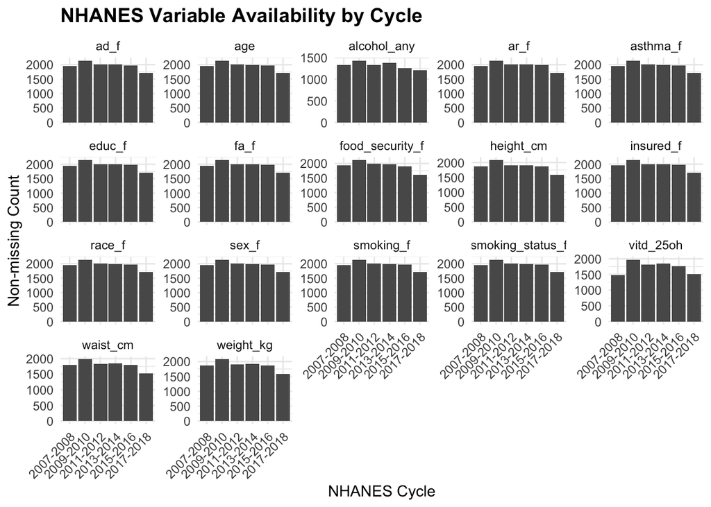

```r
# Clean modules -------------------------------------------------------------------------------

## Clean DEMO ---------------------------------------------------------------------------------

demo_clean <- demo |>
  mutate(
    sddsrvyr = SDDSRVYR,
    # Use either RIDRETH3 or RIDRETH1
    race_raw = coalesce(
      as.character(RIDRETH3),
      as.character(RIDRETH1)
    )
  ) |>
  transmute(
    seqn    = SEQN,
    age     = as.numeric(RIDAGEYR),
    sex     = RIAGENDR,
    # Collapse "Other Race - Including Multi-Racial" into "Other"
    race    = case_when(
      race_raw == "Other Race - Including Multi-Racial" ~ "Other",
      TRUE ~ race_raw
    ),
    educ    = DMDEDUC2,
    pir     = INDFMPIR,
    income_cat_demo = INDHHIN2,
    sddsrvyr,
    cycle_str = cycle_label(sddsrvyr),
    sdmvpsu  = SDMVPSU,
    sdmvstra = SDMVSTRA,
    wtint2yr = WTINT2YR,
    wtmec2yr = WTMEC2YR,
    preg     = RIDEXPRG
  )

## Clean MCQ ----------------------------------------------------------------------------------

mcq_clean <- mcq |>
  select(
    seqn       = SEQN,
    ad_raw     = MCQ160A,
    fa_raw     = MCQ160F,
    asthma_raw = MCQ010,
    ar_raw     = MCQ160B
  ) |>
  mutate(
    ad     = to01(ad_raw),
    fa     = to01(fa_raw),
    asthma = to01(asthma_raw),
    ar     = to01(ar_raw)
  )

## Clean BMX ----------------------------------------------------------------------------------

bmx_clean <- bmx |>
  transmute(
    seqn      = SEQN,
    bmi       = BMXBMI,
    waist_cm  = BMXWAIST,
    height_cm = BMXHT,
    weight_kg = BMXWT
  )

## Clean VID ----------------------------------------------------------------------------------

### Identify vitamin D lab variables (LBXVID*) that may hold 25(OH)D values
vitd_vars <- names(vid)[grepl("^LBXVID", names(vid))]

### Check whether a detection-limit flag variable exists
has_lbdvidlc <- "LBDVIDLC" %in% names(vid)

if (has_lbdvidlc) {
  # If detection-limit info is available, derive both 25(OH)D value and detection flag
  vid_clean <- vid |>
    mutate(
      # Coalesce multiple possible 25(OH)D variables into one
      vitd_25oh = reduce(across(all_of(vitd_vars)), coalesce),
      # Create a flag for being at/above vs. below detection limit
      vitd_detect = case_when(
        LBDVIDLC == 1 ~ TRUE,   # at or above detection limit
        LBDVIDLC == 0 ~ FALSE,  # below detection limit
        TRUE ~ NA
      )
    ) |>
    transmute(
      seqn = SEQN,
      vitd_25oh,
      vitd_detect
    )
} else {
  # If no detection-limit info, just keep the 25(OH)D value
  vid_clean <- vid |>
    mutate(
      vitd_25oh = reduce(across(all_of(vitd_vars)), coalesce)
    ) |>
    transmute(
      seqn = SEQN,
      vitd_25oh,
      vitd_detect = NA
    )
}

## Clean SMQ ----------------------------------------------------------------------------------

smq_clean <- smq |>
  transmute(
    seqn       = SEQN,
    smoked_100 = as.numeric(SMQ020),  # ever smoked >=100 cigarettes
    smoke_now  = as.numeric(SMQ040)   # current smoking frequency
  ) |>
  mutate(
    smoking_status = case_when(
      smoked_100 == 2 ~ "Never",
      smoked_100 == 1 & smoke_now == 3 ~ "Former",
      smoked_100 == 1 & smoke_now %in% c(1, 2) ~ "Current",
      TRUE ~ NA_character_
    )
  )

## Clean HIQ ----------------------------------------------------------------------------------

hiq_clean <- hiq |>
  transmute(
    seqn    = SEQN,
    insured = to01(HIQ011)  # 1 = insured; 0 = not insured; else NA
  )

## Clean FSQ ----------------------------------------------------------------------------------

fsq_clean <- fsq |>
  transmute(
    seqn = SEQN,
    foodsec_raw = as.numeric(FSDHH),
    food_security = case_when(
      foodsec_raw == 1 ~ "Full",
      foodsec_raw == 2 ~ "Marginal",
      foodsec_raw == 3 ~ "Low",
      foodsec_raw == 4 ~ "Very low",
      TRUE ~ NA_character_
    )
  )

## Clean ALQ ----------------------------------------------------------------------------------

alq_clean <- alq |>
  transmute(
    seqn         = SEQN,
    alcohol_freq = ALQ130
  ) |>
  mutate(
    # alcohol_any = 1 if any reported drinking in past 12 months, 0 if none
    alcohol_any = case_when(
      is.na(alcohol_freq) ~ NA_real_,
      alcohol_freq %in% c(777, 999) ~ NA_real_,  # refused / don't know
      alcohol_freq == 0 ~ 0,
      alcohol_freq > 0  ~ 1
    )
  )

# Merge modules -------------------------------------------------------------------------------

nhanes_all <- demo_clean |>
  left_join(mcq_clean,  by = "seqn") |>
  left_join(bmx_clean,  by = "seqn") |>
  left_join(vid_clean,  by = "seqn") |>
  left_join(smq_clean,  by = "seqn") |>
  left_join(hiq_clean,  by = "seqn") |>
  left_join(fsq_clean,  by = "seqn") |>
  left_join(alq_clean,  by = "seqn")

# Filter to study population ------------------------------------------------------------------

nhanes_analytic <- nhanes_all |>
  # Adults age 20–40 years
  filter(age >= 20, age <= 40) |>
  # Exclude pregnant participants
  filter(
    is.na(preg) |
      !preg %in% c(
        "Yes, positive lab pregnancy test or self-reported pregnant at exam"
      )
  ) |>
  mutate(
    # 12-year combined interview and MEC weights
    wtint12yr = wtint2yr / length(cycles),
    wtmec12yr = wtmec2yr / length(cycles),

    # Sex factors
    sex_f = factor(
      as.character(sex),
      levels = c("Male", "Female")
      ),

    ##Smoking factors
    smoking_f = factor(smoking_status,
                       levels = c("Never", "Former", "Current")),

    # Allergic outcome factors
    ad_f     = factor(ad,     levels = c(0, 1), labels = c("No", "Yes")),
    ar_f     = factor(ar,     levels = c(0, 1), labels = c("No", "Yes")),
    fa_f     = factor(fa,     levels = c(0, 1), labels = c("No", "Yes")),
    asthma_f = factor(asthma, levels = c(0, 1), labels = c("No", "Yes")),

    # Education factor
    educ_f = factor(educ),

    ## Food security factor
    food_security_f = factor(
      food_security,
      levels  = c("Full", "Marginal", "Low", "Very low"),
      ordered = TRUE
    ),

    # Insurance indicator factor
    insured_f = factor(
      insured,
      levels = c(0, 1),
      labels = c("No", "Yes")
    ),

    # Race factor
    race_f = factor(race),

    # Smoking status factor
    smoking_status_f = factor(
      smoking_status,
      levels = c("Never", "Former", "Current")
    ),

    # Pregnancy flag
    preg_flag = case_when(
      preg == "Yes, positive lab pregnancy test or self-reported pregnant at exam" ~ 1,
      preg %in% c(
        "SP not pregnant at exam",
        "The participant was not pregnant at exam"
      ) ~ 0,
      preg %in% c(
        "Cannot ascertain if SP is pregnant at exam",
        "Cannot ascertain if the participant is pregnant at exam"
      ) ~ NA_real_,
      TRUE ~ NA_real_
    ),
    preg_flag_f = factor(
      preg_flag,
      levels = c(0, 1),
      labels = c("Not pregnant", "Pregnant")
    )
  )

# Incorporate survey designs ------------------------------------------------------------------

des_int_12yr <- svydesign(
  ids     = ~sdmvpsu,
  strata  = ~sdmvstra,
  weights = ~wtint12yr,
  nest    = TRUE,
  data    = nhanes_analytic
)

des_mec_12yr <- svydesign(
  ids     = ~sdmvpsu,
  strata  = ~sdmvstra,
  weights = ~wtmec12yr,
  nest    = TRUE,
  data    = nhanes_analytic
)

# Check variable availability across cycles ---------------------------------------------------

## Variables of interest
vars_focus <- c(
  "ad_f",
  "age",
  "alcohol_any",
  "ar_f",
  "asthma_f",
  "bpi",
  "educ_f",
  "fa_f",
  "food_security_f",
  "height_cm",
  "insured_f",
  "race_f",
  "sex_f",
  "smoking_f",
  "smoking_status_f",
  "vitd_25oh",
  "waist_cm",
  "weight_kg"
)

## Check availability of full set of variables
availability_all <- check_var_availability(nhanes_analytic)

## Check availability of variables of interest
availability_sel <- availability_all |>
  filter(variable %in% vars_focus)

## Add cycle labels and ordering
availability_sel <- availability_sel |>
  mutate(
    cycle_label = cycle_label(cycle),
    cycle_label = factor(
      cycle_label,
      levels = c(
        "2007-2008",
        "2009-2010",
        "2011-2012",
        "2013-2014",
        "2015-2016",
        "2017-2018"
      )
    )
  )

## Plot availability for selected variables
availability_sel |>
  ggplot(aes(x = cycle_label, y = n_nonmissing)) +
  geom_col() +
  facet_wrap(~ variable, scales = "free_y") +
  labs(
    x = "NHANES Cycle",
    y = "Non-missing Count",
    title = "NHANES Variable Availability by Cycle"
  ) +
  theme_minimal() +
  theme(
    axis.text.x = element_text(angle = 45, hjust = 1),
    plot.title  = element_text(size = 14, face = "bold")
  )
```

## 4 Results

**Describe your results and include relevant tables, plots, and code/comments used to obtain them. You may refer to the Section 3 as needed. End with a brief conclusion of your findings related to the question you set out to address. You can include references if you’d like, but this is not required.**

```r
# Weighted allergic disease prevalence
svymean(~asthma + ad + ar + fa, des_int_12yr, na.rm = TRUE)
```

```
            mean     SE
asthma 0.1668152 0.0046
ad     0.0661429 0.0030
ar     0.0032506 0.0006
fa     0.0041966 0.0007
```

```r
# Weighted means for BMI
svymean(~bmi, des_mec_12yr, na.rm = TRUE)
```

```
     mean     SE
bmi 28.46 0.1286
```

```r
# Weighted means for 25(OH) vitamin D level
svymean(~vitd_25oh, des_mec_12yr, na.rm = TRUE)
```

```
            mean     SE
vitd_25oh 62.756 0.6442
```

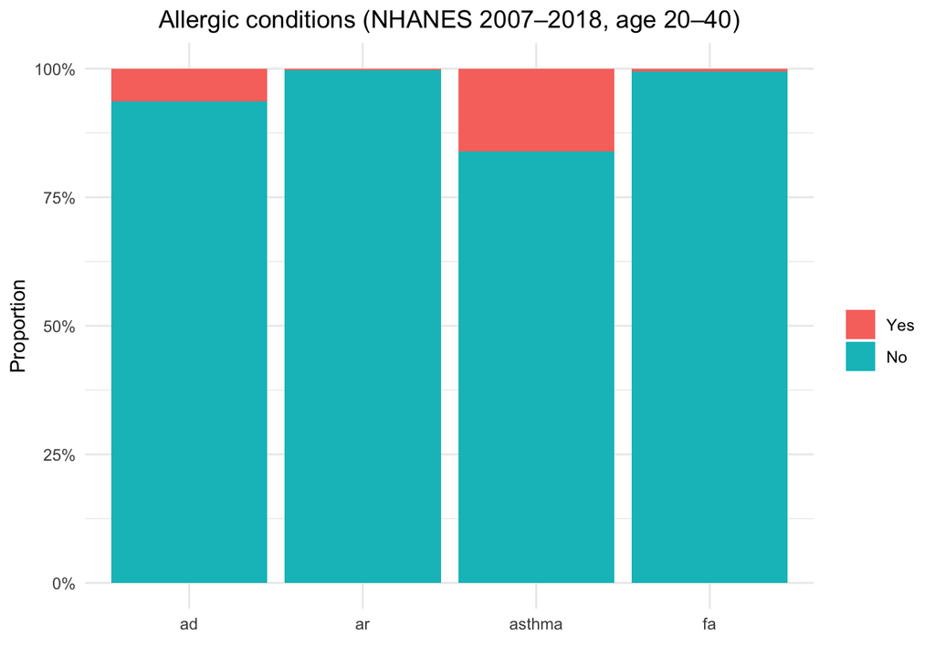

```r
# Unweighted means for allergic conditions
nhanes_analytic |>
  pivot_longer(
    cols = c(asthma, ad, ar, fa),
    names_to = "condition",
    values_to = "value"
  ) |>
  filter(!is.na(value)) |>
  ggplot(aes(
    x = condition,
    fill = factor(value, levels = c(1, 0), labels = c("Yes", "No"))
  )) +
  geom_bar(position = "fill") +
  scale_y_continuous(labels = percent) +
  labs(
    x = "",
    y = "Proportion",
    fill = "",
    title = "Allergic conditions (NHANES 2007–2018, age 20–40)"
  ) +
  theme_minimal() +
  theme(
    plot.title = element_text(hjust = 0.5)
  )
```

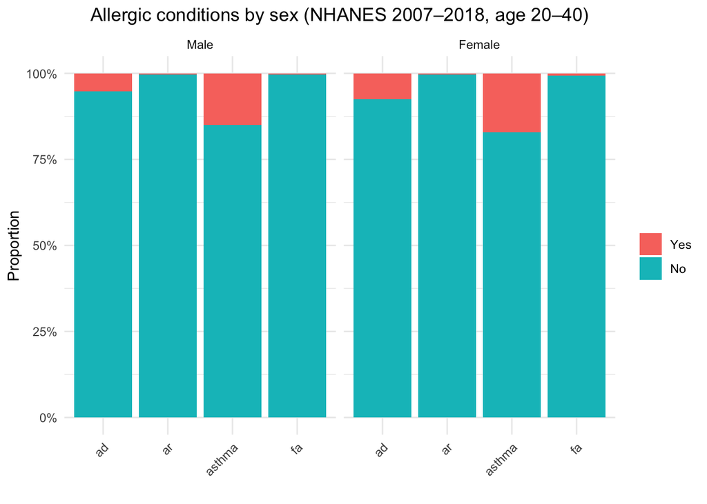

```r
# Unweighted prevalence plots stratified by sex
nhanes_analytic |>
  pivot_longer(
    cols = c(asthma, ad, ar, fa),
    names_to = "condition",
    values_to = "value"
  ) |>
  filter(!is.na(value), !is.na(sex_f)) |>
  ggplot(aes(
    x = condition,
    fill = factor(value, levels = c(1, 0), labels = c("Yes", "No"))
  )) +
  geom_bar(position = "fill") +
  facet_wrap(~ sex_f) +
  scale_y_continuous(labels = percent) +
  labs(
    x = "",
    y = "Proportion",
    fill = "",
    title = "Allergic conditions by sex (NHANES 2007–2018, age 20–40)"
  ) +
  theme_minimal() +
  theme(
    plot.title  = element_text(hjust = 0.5),
    axis.text.x = element_text(angle = 45, hjust = 1)
  )
```

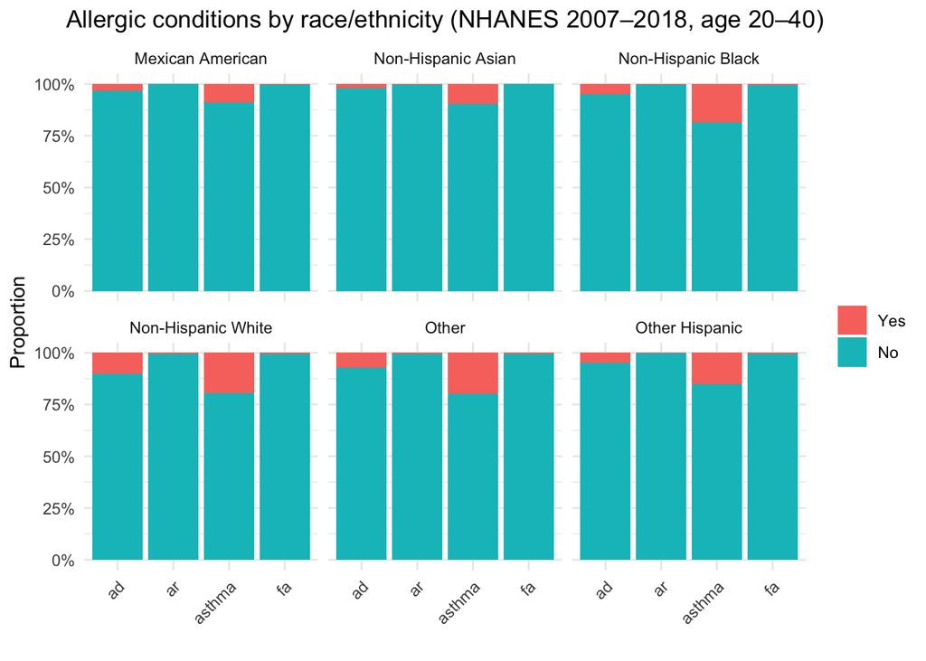

```r
# Unweighted prevalence plots stratified by race
nhanes_analytic |>
  pivot_longer(
    cols = c(asthma, ad, ar, fa),
    names_to = "condition",
    values_to = "value"
  ) |>
  filter(!is.na(value), !is.na(race)) |>
  ggplot(aes(
    x = condition,
    fill = factor(value, levels = c(1, 0), labels = c("Yes", "No"))
  )) +
  geom_bar(position = "fill") +
  facet_wrap(~ race) +
  scale_y_continuous(labels = percent) +
  labs(
    x = "",
    y = "Proportion",
    fill = "",
    title = "Allergic conditions by race/ethnicity (NHANES 2007–2018, age 20–40)"
  ) +
  theme_minimal() +
  theme(
    plot.title  = element_text(hjust = 0.5),
    axis.text.x = element_text(angle = 45, hjust = 1)
  )
```

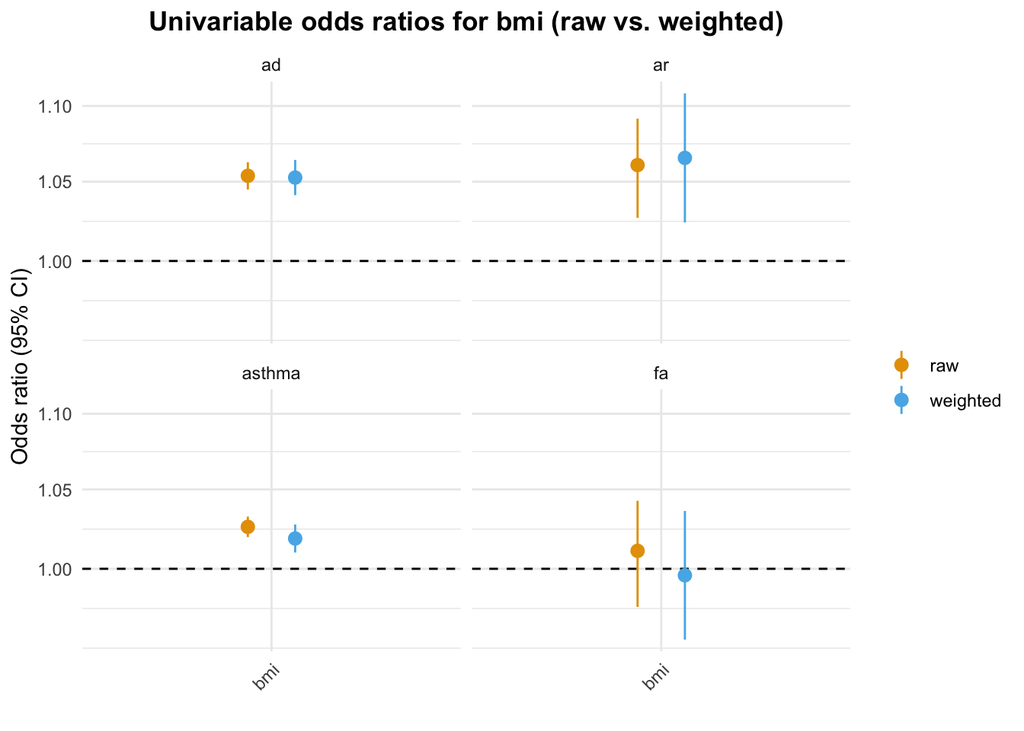

```r
# Compare unweighted vs. weighted univariable logistic regression------------------------------

## Colors for raw vs. weighted in OR plots
man_cols <- c("raw" = "#E69F00", "weighted" = "#56B4E9")

## Fit unweighted glm and weighted svyglm for a given outcome and exposure
comp <- function(outcome, exposure) {
  ## Dataset
  data_sub   <- nhanes_analytic
  ## Survey design
  design_sub <- des_mec_12yr
  fmla <- as.formula(paste0(outcome, " ~ ", exposure))

  # Unweighted logistic regression
  glm_mod <- glm(fmla, data = data_sub, family = binomial()) |>
    tidy(conf.int = TRUE, exponentiate = TRUE) |>
    mutate(method = "raw")

  # Weighted logistic regression
  svyglm_mod <- svyglm(fmla, design = design_sub, family = quasibinomial()) |>
    tidy(conf.int = TRUE, exponentiate = TRUE) |>
    mutate(method = "weighted")

  bind_rows(glm_mod, svyglm_mod) |>
    filter(term != "(Intercept)") |>
    mutate(
      outcome  = outcome,
      exposure = exposure,
      .before  = 1
    )
}

## Outcomes and exposures to analyze
outcomes  <- c("asthma", "ad", "ar", "fa")
exposures <- c("bmi", "vitd_25oh")

## Run univariable models
results_uni <- lapply(outcomes, function(o) {
  lapply(exposures, function(x) comp(o, x)) |> bind_rows()
}) |> bind_rows()

# Plot ORs for a given exposure across outcomes (raw vs weighted)------------------------------
## Plot function
plot_uni <- function(exposure_name) {
  results_uni |>
    filter(exposure == exposure_name) |>
    ggplot(aes(x = term, y = estimate, color = method)) +
    geom_hline(yintercept = 1, linetype = "dashed") +
    geom_pointrange(
      aes(ymin = conf.low, ymax = conf.high),
      position = position_dodge(0.3)
    ) +
    facet_wrap(~ outcome) +
    scale_color_manual(values = man_cols) +
    scale_y_continuous(trans = "log10") +
    labs(
      title = paste("Univariable odds ratios for", exposure_name,
                    "(raw vs. weighted)"),
      x = "",
      y = "Odds ratio (95% CI)",
      color = ""
    ) +
    theme_minimal() +
    theme(
      plot.title  = element_text(hjust = 0.5, face = "bold"),
      axis.text.x = element_text(angle = 45, hjust = 1)
    )
}

## Generate OR plots for variables of interest
plot_uni("bmi")
```

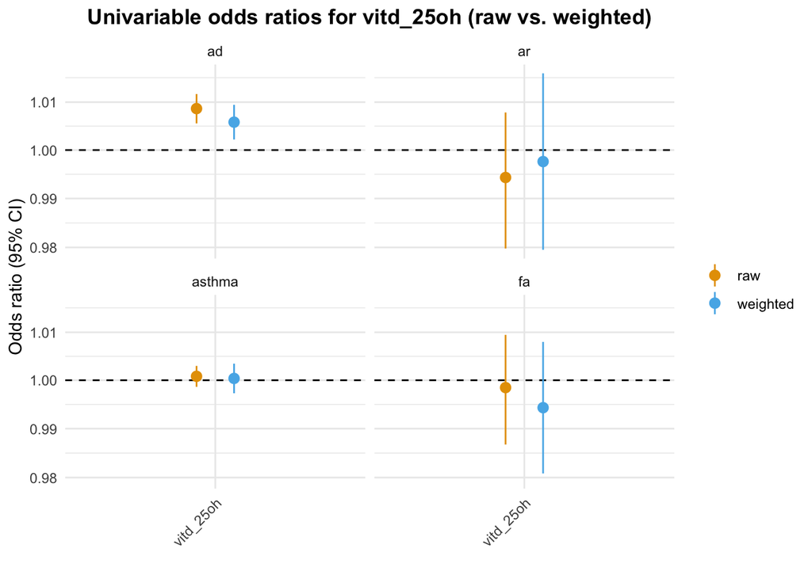

```r
plot_uni("vitd_25oh")
```

```r
## ORs and CIs for all analyses
results_uni |>
  select(outcome, exposure, method, estimate, conf.low, conf.high)
```

```
# A tibble: 16 × 6
   outcome exposure  method   estimate conf.low conf.high
   <chr>   <chr>     <chr>       <dbl>    <dbl>     <dbl>
 1 asthma  bmi       raw         1.03     1.02       1.03
 2 asthma  bmi       weighted    1.02     1.01       1.03
 3 asthma  vitd_25oh raw         1.00     0.999      1.00
 4 asthma  vitd_25oh weighted    1.00     0.997      1.00
 5 ad      bmi       raw         1.05     1.04       1.06
 6 ad      bmi       weighted    1.05     1.04       1.06
 7 ad      vitd_25oh raw         1.01     1.01       1.01
 8 ad      vitd_25oh weighted    1.01     1.00       1.01
 9 ar      bmi       raw         1.06     1.03       1.09
10 ar      bmi       weighted    1.07     1.02       1.11
11 ar      vitd_25oh raw         0.994    0.980      1.01
12 ar      vitd_25oh weighted    0.998    0.980      1.02
13 fa      bmi       raw         1.01     0.977      1.04
14 fa      bmi       weighted    0.996    0.957      1.04
15 fa      vitd_25oh raw         0.998    0.987      1.01
16 fa      vitd_25oh weighted    0.994    0.981      1.01
```